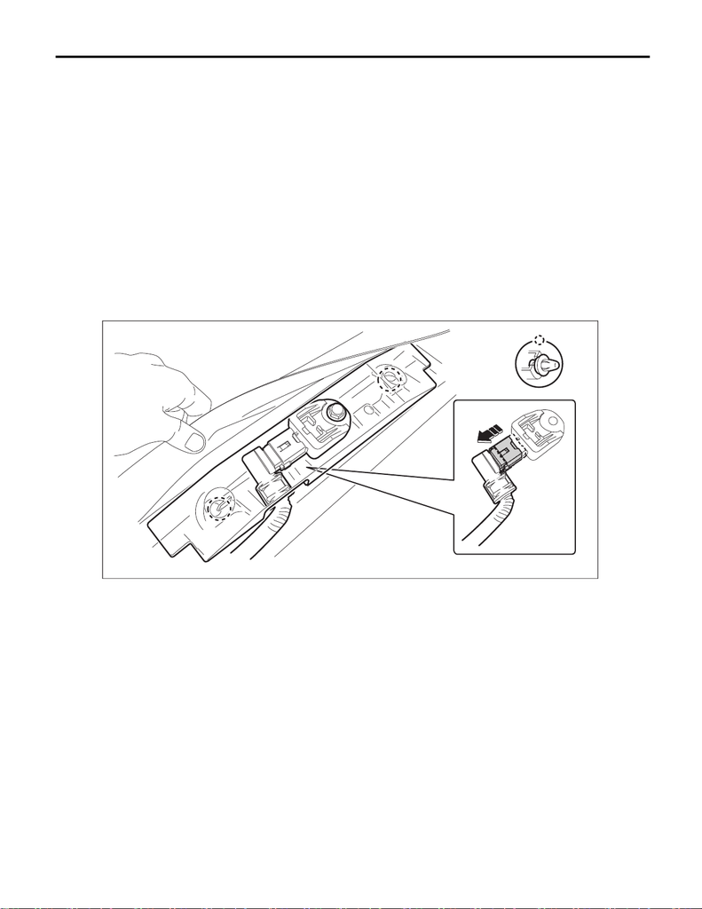

Satellite Safing Sensor

AIRBAG SYSTEM

14.Satellite Safing Sensor

A: REMOVAL

CAUTION:

The airbag system is fitted with a backup power supply. After disconnecting the battery ground ca-

ble, the airbag may operate if you do not wait for 60 seconds before starting the service of airbag sys-

tem.

1) Turn the ignition switch to OFF.

2) Disconnect the ground cable from battery and wait for at least 60 seconds before starting work. <Ref. to

NT-5, BATTERY, NOTE, Note.>

NOTE:

For models other than STI model, disconnect the ground terminal from battery sensor.

3) Remove the rear seat cushion assembly. <Ref. to SE-29, REMOVAL, Rear Seat.>

4) Remove the satellite safing sensor.

(1) Remove the clip, and remove the cover - satellite safing.

(2) Remove the bolts and then remove the satellite safing sensor. <Ref. to AB-21, FRONT DOOR IM-

PACT SENSOR AND SATELLITE SAFING SENSOR, PROCEDURE, Airbag Connector.>

B: INSTALLATION

1) Install the satellite safing sensor.

CAUTION:

• Do not reuse the bolt and nut.

Always replace with the specified new bolts and nuts.

• When installing the cover - satellite safing, push the cover securely until it contacts the floor panel.

• If the cover - satellite safing is too loose at its mounting portion to remove easily, replace with a

new cover - satellite safing.

• After installing the cover - satellite safing, make sure that the sensor harness does not get caught.

Tightening torque:

7.5 N·m (0.8 kgf-m, 5.5 ft-lb)

2) Install the rear seat cushion assembly.

3) Connect the battery ground terminal. <Ref. to NT-5, BATTERY, NOTE, Note.>

NOTE:

For models other than STI model, connect the ground terminal to battery sensor.

[figure not shown]

Satellite Safing Sensor

AIRBAG SYSTEM

C: INSPECTION

Check for the following, and replace the damaged parts with new parts.

• The satellite safing sensor connector is damaged.

• The cover - satellite safing is damaged

• Side airbag or curtain airbag has been activated.